# Исследование объявлений о продаже квартир

#### **Зависимость Цены от этажа, на котором расположена квартира (первый, последний, другой)**

```python
data.groupby('floor_category')['last_price'].count()
```

```
floor_category
другой       17094
первый        2870
последний     3232
Name: last_price, dtype: int64
```

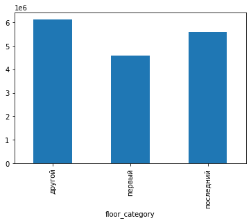

```python
data.groupby('floor_category')['last_price'].mean().plot(kind='bar')
```

**Гистограмма показывает - первый этаж любят меньше всего - поэтому средняя цена ниже всех(чем меньше спрос, тем меньше цена). Более предпочтителен другой этах - не первый и не последний - на него цена выше.**

#### **Зависимость Цены от даты размещения (день недели, месяц, год).**

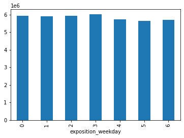

```python
data.groupby('exposition_weekday')['last_price'].mean().plot(kind='bar')
```

```
-0.018314994653585447
```

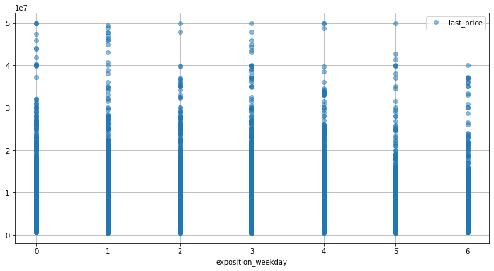

```python
data.plot(x = 'exposition_weekday', y = 'last_price', style='o', grid=True, figsize=(12, 6), alpha=0.5)
data['exposition_weekday'].corr(data['last_price'])
```

```
0.0008839709037235873
```

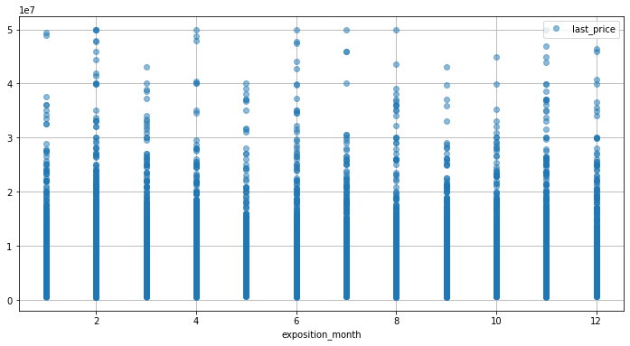

```python
data.plot(x = 'exposition_month', y = 'last_price', style='o', grid=True, figsize=(12, 6), alpha=0.5)
data['exposition_month'].corr(data['last_price'])
```

```
-0.03890142667783417
```

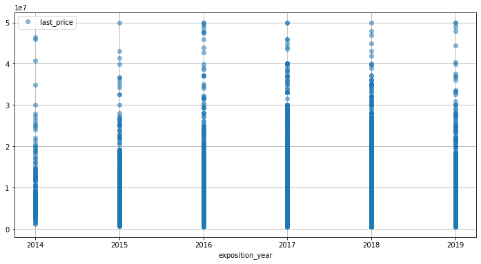

```python
data.plot(x = 'exposition_year', y = 'last_price', style='o', grid=True, figsize=(12, 6), alpha=0.5)
data['exposition_year'].corr(data['last_price'])
```

### Посчитайте среднюю цену одного квадратного метра в 10 населённых пунктах с наибольшим числом объявлений. Выделите населённые пункты с самой высокой и низкой стоимостью квадратного метра.

```python
data.groupby('locality_name')['price_one_square_meter'].agg(['count', 'mean','median','min','max']).sort_values(by='count', ascending=False).head(10)
```

| locality_name | count | mean | median | min | max |
| --- | --- | --- | --- | --- | --- |
| Санкт-Петербург | 15329 | 112162.130174 | 104494.380 | 15345.27 | 848484.85 |
| посёлок Мурино | 584 | 86017.231884 | 86250.375 | 50000.00 | 138580.25 |
| Кудрово | 470 | 95260.846128 | 95555.315 | 54160.35 | 160401.00 |
| посёлок Шушары | 437 | 78554.913776 | 76829.270 | 47700.42 | 147826.09 |
| Всеволожск | 398 | 68654.473970 | 65789.470 | 31400.00 | 640422.35 |
| Пушкин | 360 | 102873.389194 | 99865.715 | 59836.07 | 256521.74 |
| Колпино | 337 | 75333.295816 | 74722.220 | 47957.37 | 125000.00 |
| посёлок Парголово | 326 | 90332.262638 | 91780.225 | 48405.47 | 138522.43 |
| Гатчина | 307 | 68746.146515 | 67796.610 | 10507.25 | 146315.79 |
| Выборг | 237 | 58141.909325 | 58158.320 | 18750.00 | 107473.12 |

**В таблице приведены населенные пункты с самым большим количеством объявлений , по ним посчитана средняя стояимость квадратного метра.Самая высокая стоимость в Санкт-Петербурге и самая низкая в Выборге**

### Теперь выделите квартиры в Санкт-Петербурге с помощью столбца locality_name и вычислите среднюю цену каждого километра. Опишите, как стоимость объектов зависит от расстояния до центра города.

```python
#Создадим новый датафрейм и оставим только значения по Санкт-петербургу
spb = data.loc[data['locality_name']=='Санкт-Петербург',['last_price', 'city_centers_nearest']].reset_index(drop=True)
```

```python
#удалим пустые значения
spb = spb.dropna(subset=['city_centers_nearest'])
```

```python
#Добавим новый столбец где сохраним данные расстояния в км и сделаем его int
spb['dist_center_km'] = round(spb['city_centers_nearest']/1000).astype(int)
print(spb.head(10))
```

```
   last_price  city_centers_nearest  dist_center_km
0    13000000               16028.0              16
1     5196000               13933.0              14
2    10000000                8098.0               8
3     7915000               11634.0              12
4     5400000               15008.0              15
5     5050000               13878.0              14
6     4650000               14259.0              14
7     6700000               10698.0              11
8     4180000               14616.0              15
9     3250000               10842.0              11
```

```python
#
spb_dist_c = spb.pivot_table(index='dist_center_km',values='last_price',aggfunc=('count','mean'))
print(spb_dist_c.round())
```

```
                 count        mean
dist_center_km
0                 23.0  20577462.0
1                170.0  12593171.0
2                277.0  11884733.0
3                338.0  10108028.0
4                660.0  10766904.0
5                854.0  11303934.0
6                564.0  11158731.0
7                392.0  11281383.0
8                584.0   8852523.0
9                588.0   6928807.0
10               713.0   6364743.0
11              1161.0   6107232.0
12              1590.0   5788933.0
```

[output cut: 17 more lines]

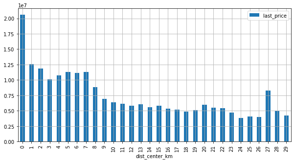

```python
#Построим график
spb.pivot_table(index='dist_center_km',values='last_price',aggfunc=('mean')).plot(kind='bar',grid=True, figsize=(10,5))
```

**Судя по гистограмме видно , что чем ближе к центру тем дороже квартиры, после 7 км начинается уменьшение. 27 км какой то выброс, предположительно элитный район**